# Lab 5

#### class weight and recall

```
[[151  72]
 [563 631]]
              precision    recall  f1-score   support

           0       0.21      0.68      0.32       223
           1       0.90      0.53      0.67      1194

    accuracy                           0.55      1417
   macro avg       0.55      0.60      0.49      1417
weighted avg       0.79      0.55      0.61      1417
```

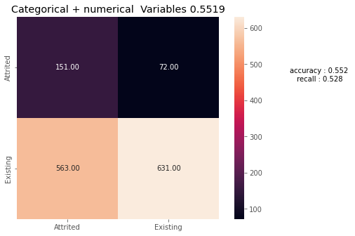

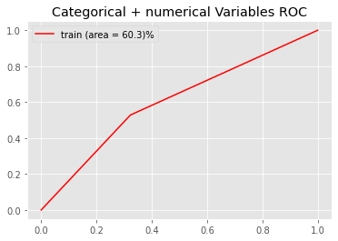

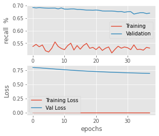

```
CPU times: user 21.6 s, sys: 4.68 s, total: 26.3 s
Wall time: 13.6 s
```

```python
%%time


model.compile(optimizer=keras.optimizers.Adam(learning_rate=0.01,epsilon=0.1),
              loss=tf.keras.losses.BinaryCrossentropy(),
              metrics=[tf.keras.metrics.AUC(name="recall")])


callback = tf.keras.callbacks.EarlyStopping(monitor='val_recall', patience=5)

weight_0 = 1/len(y_train[y_train==0])
weight_1 = 1/len(y_train[y_train==1])
class_weight = {0: weight_0, 1: weight_1}

history = model.fit([X_train_crossed,X_train_cat,X_train_num],
                    y_train_crossed,
                    epochs=50,
                    batch_size=32,
                    verbose=0,
                    callbacks=[callback],
                    validation_data = ([X_test_crossed,X_test_cat,X_test_num],y_test_crossed),
                    class_weight=class_weight)

yhat = model.predict([X_test_crossed,X_test_cat,X_test_num]) # each branch has an input

yhat = np.round(yhat)
print(mt.confusion_matrix(y_test,yhat))
print(mt.classification_report(y_test,yhat))

summarize_net(model,yhat,y_test.to_numpy(),"Categorical + numerical  Variables ")
plt.show()
plt.figure()
plot_roc(0,"Categorical + numerical Variables ROC",y_test.to_numpy(),yhat)
plot_train_val("recall ",history.history['recall'],history.history['val_recall'],history.history['loss'],history.history['val_loss'])
```

#### Class weight and Accuracy

```
[[  17  206]
 [  27 1167]]
              precision    recall  f1-score   support

           0       0.39      0.08      0.13       223
           1       0.85      0.98      0.91      1194

    accuracy                           0.84      1417
   macro avg       0.62      0.53      0.52      1417
weighted avg       0.78      0.84      0.79      1417
```

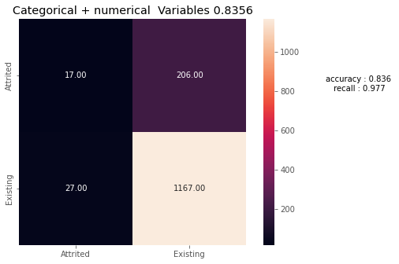

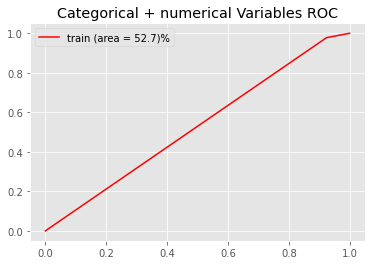

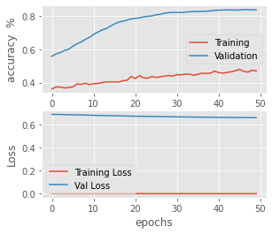

```
CPU times: user 25.3 s, sys: 5.64 s, total: 30.9 s
Wall time: 16.4 s
```

```python
%%time


model.compile(optimizer=keras.optimizers.Adam(learning_rate=0.01,epsilon=0.1),
              loss=tf.keras.losses.BinaryCrossentropy(),
              metrics=['accuracy'])


callback = tf.keras.callbacks.EarlyStopping(monitor='val_accuracy', patience=5)

weight_0 = 1/len(y_train[y_train==0])
weight_1 = 1/len(y_train[y_train==1])
class_weight = {0: weight_0, 1: weight_1}

history = model.fit([X_train_crossed,X_train_cat,X_train_num],
                    y_train_crossed,
                    epochs=50,
                    batch_size=32,
                    verbose=0,
                    callbacks=[callback],
                    validation_data = ([X_test_crossed,X_test_cat,X_test_num],y_test_crossed),
                    class_weight=class_weight)

yhat = model.predict([X_test_crossed,X_test_cat,X_test_num]) # each branch has an input

yhat = np.round(yhat)
print(mt.confusion_matrix(y_test,yhat))
print(mt.classification_report(y_test,yhat))

summarize_net(model,yhat,y_test.to_numpy(),"Categorical + numerical  Variables ")
plt.show()
plt.figure()
plot_roc(0,"Categorical + numerical Variables ROC",y_test.to_numpy(),yhat)
plot_train_val("accuracy ",history.history['accuracy'],history.history['val_accuracy'],history.history['loss'],history.history['val_loss'])
```

Using class weight and accuracy rather than class weight and recall on this model, we still get pretty poor results. It is clear that our original model with less layers performs far better. Our loss graph is atrocious again, and the accuracy graph puts training at such a low accuracy that it raises some pretty serious questions. The recall for attrited customers is at a devastatingly low 8%, and the f1 score for attrited customers is 13%. Funnily enough, the accuracy is 84%, which is exactly what it would be if our model guessed everyone was an existing customer. However, we know this is not the case, as the recall for the attrited customers is not at 0%. Let's see if the AUC performs better, but even from this two tests, it seems clear that our wide and deep network with class weights and fewer layers performs optimally.

#### Class weight and AUC

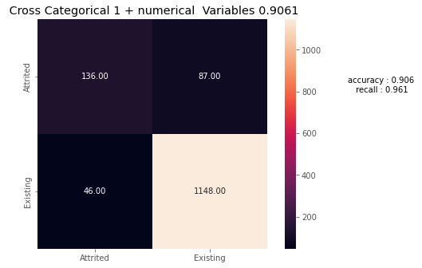

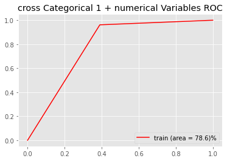

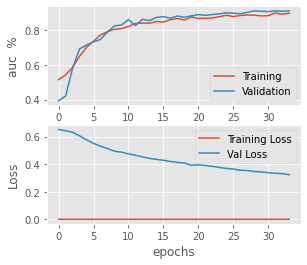

```
CPU times: user 19.1 s, sys: 4.08 s, total: 23.2 s
Wall time: 12.2 s
```

```python
%%time

model.compile(optimizer='adam',
              loss=tf.keras.losses.BinaryCrossentropy(),
              metrics=[tf.keras.metrics.AUC(name="auc")])

callback = tf.keras.callbacks.EarlyStopping(monitor='val_auc', patience=5)

weight_0 = 1/len(y_train[y_train==0])
weight_1 = 1/len(y_train[y_train==1])
class_weight = {0: weight_0, 1: weight_1}

history = model.fit([X_train_crossed,X_train_cat,X_train_num],
                    y_train,
                    epochs=50,
                    batch_size=32,
                    verbose=0,
                    callbacks=[callback],
                    class_weight=class_weight,
                    validation_data = ([X_test_crossed,X_test_cat,X_test_num],y_test_crossed))

yhat = model.predict([X_test_crossed,X_test_cat,X_test_num]) # each branch has an input
yhat=np.round(yhat)
summarize_net(model,yhat,y_test.to_numpy()," Cross Categorical 1 + numerical  Variables ")
plt.show()
plt.figure()
plot_roc(0,"cross Categorical 1 + numerical Variables ROC",y_test.to_numpy(),yhat)
plot_train_val("auc ",history.history['auc'],history.history['val_auc'],history.history['loss'],history.history['val_loss'])
```

Using the same model with numerous layers, but training on an AUC metric instead of recall or accuracy, we see more hopeful results. Accuracy is up to 91%, with recall averaging around 96%, which is the best we've seen so far but we can't get too excited yet. Next, we look at the graphs. Training loss is still at 0 the whole time, but on the bright side, validation loss decreases as epochs increase, showing some improvement in the model. Finally, the AUC graph keeps a consistent relationship between training and validation, which is honestly refreshing after looking at so many inconsistent graphs earlier. This model is still not optimal, but it's the best we've seen out of all of the wide and deep networks with added layers beyond our first runs.

```python
X = normalized_df.drop(["Attrition_Flag"], axis=1)
y = normalized_df["Attrition_Flag"]

X_train, X_test, y_train, y_test = train_test_split(X, y, test_size=0.20, random_state = 42, shuffle=True)
```

```python
# adding df_train and df_test

df_x_train = pd.DataFrame (X_train)
df_x_test = pd.DataFrame (X_test)
df_y_train = pd.DataFrame (y_train)
df_y_test = pd.DataFrame (y_test)

train_dfs = [df_x_train, df_y_train]
test_dfs = [df_x_test, df_y_test]

df_train = pd.concat(train_dfs)
df_test = pd.concat(test_dfs)
```

Now it's time to cross different columns, and see if we get better results using these.

```python
print(X_train.shape)
```

```
(8101, 26)
```

```python
cross_columns = [['Gender','Income_Category'],
                 ['Education_Level','Marital_Status'],
                 ['Education_Level','Income_Category'],
                 ['Gender','Education_Level']
                ]

# cross each set of columns in the list above
cross_col_df_names = []
for cols_list in cross_columns:
    # encode as ints for the embedding
    enc = LabelEncoder()

    # 1. create crossed labels by join operation
    X_crossed_train = df[cols_list].apply(lambda x: '_'.join(map(str, x)), axis=1)

    # get a nice name for this new crossed column
    cross_col_name = '_'.join(map(str, cols_list))

    # 3. Save into dataframe with new name
    df[cross_col_name] = enc.fit_transform(X_crossed_train)


    # Save the encoder used here for later:
    encoders[cross_col_name] = enc

    # keep track of the new names of the crossed columns
    cross_col_df_names.append(cross_col_name)

cross_col_df_names
```

```
['Gender_Income_Category',
 'Education_Level_Marital_Status',
 'Education_Level_Income_Category',
 'Gender_Education_Level']
```

```python
X_train_crossed, X_test_crossed, y_train_crossed, y_test_crossed = train_test_split(df , df["Attrition_Flag_int"] , test_size=0.20, random_state=42,stratify=df["Attrition_Flag_int"])


# save categorical features
X_train_cat = X_train_crossed[categorical_headers_ints].to_numpy()
X_test_cat = X_test_crossed[categorical_headers_ints].to_numpy()

# and save off the numeric features
X_train_num =  X_train_crossed[numeric_headers].to_numpy()
X_test_num = X_test_crossed[numeric_headers].to_numpy()

# get crossed columns
X_train_crossed = X_train_crossed[cross_col_df_names].to_numpy()
X_test_crossed = X_test_crossed[cross_col_df_names].to_numpy()


ss = StandardScaler()
X_train_num = ss.fit_transform(X_train_num)
X_test_num = ss.transform(X_test_num)


# we need to create separate lists for each branch
crossed_outputs = []

# CROSSED DATA INPUT
input_crossed = Input(shape=(X_train_crossed.shape[1],), dtype='int64', name='wide_inputs')
for idx,col in enumerate(cross_col_df_names):

    # track what the maximum integer value will be for this variable
    # which is the same as the number of categories
    N = max(df[col].max(),df[col].max())+1
    # N = len(encoders[col].classes_)
    N_reduced = int(np.sqrt(N))


    # this line of code does this: input_branch[:,idx]
    x = tf.gather(input_crossed, idx, axis=1)

    # now use an embedding to deal with integers as if they were one hot encoded
    x = Embedding(input_dim=N,
                  output_dim=N_reduced,
                  input_length=1, name=col+'_embed')(x)

    # save these outputs to concatenate later
    crossed_outputs.append(x)


# now concatenate the outputs and add a fully connected layer
wide_branch = concatenate(crossed_outputs, name='wide_concat')

# reset this input branch
all_deep_branch_outputs = []

# CATEGORICAL DATA INPUT
input_cat = Input(shape=(X_train_cat.shape[1],), dtype='int64', name='categorical_input')
for idx,col in enumerate(categorical_headers_ints):

    # track what the maximum integer value will be for this variable
    # which is the same as the number of categories
    N = max(df[col].max(),df[col].max())+1
    N_reduced = int(np.sqrt(N))

    # this line of code does this: input_branch[:,idx]
    x = tf.gather(input_cat, idx, axis=1)

    # now use an embedding to deal with integers as if they were one hot encoded
    x = Embedding(input_dim=N,
                  output_dim=N_reduced,
                  input_length=1, name=col+'_embed')(x)

    # save these outputs to concatenate later
    all_deep_branch_outputs.append(x)

# NUMERIC DATA INPUT
# create dense input branch for numeric
input_num = Input(shape=(X_train_num.shape[1],), name='numeric')
x_dense = Dense(units=20, activation='relu',name='num_1')(input_num)

all_deep_branch_outputs.append(x_dense)


# merge the deep branches together
deep_branch = concatenate(all_deep_branch_outputs,name='concat_embeds')
deep_branch = Dense(units=50,activation='relu', name='deep1')(deep_branch)
deep_branch = Dense(units=25,activation='relu', name='deep2')(deep_branch)
deep_branch = Dense(units=10,activation='relu', name='deep3')(deep_branch)

# merge the deep and wide branch
final_branch = concatenate([wide_branch, deep_branch],
                           name='concat_deep_wide')
final_branch = Dense(units=1,activation='sigmoid',
                     name='combined')(final_branch)

model = Model(inputs=[input_crossed,input_cat,input_num],
              outputs=final_branch)
```

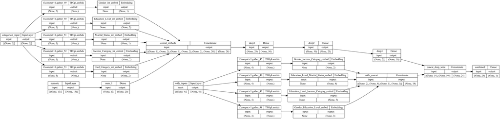

```python
plot_model(
    model, to_file='model.png', show_shapes=True, show_layer_names=True,
    rankdir='LR', expand_nested=False, dpi=96
)
```

#### Unweighted

```
[[   0  223]
 [   0 1194]]
              precision    recall  f1-score   support

           0       0.00      0.00      0.00       223
           1       0.84      1.00      0.91      1194

    accuracy                           0.84      1417
   macro avg       0.42      0.50      0.46      1417
weighted avg       0.71      0.84      0.77      1417
```

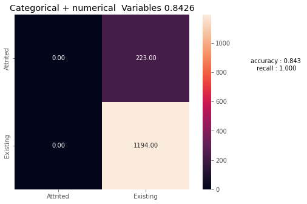

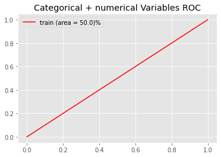

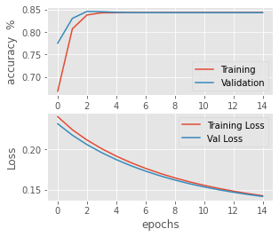

```
CPU times: user 8.07 s, sys: 1.21 s, total: 9.28 s
Wall time: 6.13 s
```

```python
%%time

model.compile(optimizer='adagrad',
              loss='mean_squared_error',
              metrics=['accuracy'])

# lets also add the history variable to see how we are doing
# and lets add a validation set to keep track of our progress
history = model.fit([X_train_crossed,X_train_cat,X_train_num],
                    y_train_crossed,
                    epochs=15,
                    batch_size=32,
                    verbose=1,
                    validation_data = ([X_test_crossed,X_test_cat,X_test_num],y_test_crossed))

yhat = model.predict([X_test_crossed,X_test_cat,X_test_num]) # each branch has an input

yhat = np.round(yhat)
print(mt.confusion_matrix(y_test_crossed,yhat))
print(mt.classification_report(y_test_crossed,yhat))

summarize_net(model,yhat,y_test_crossed.to_numpy(),"Categorical + numerical  Variables ")
plt.show()
plt.figure()
plot_roc(0,"Categorical + numerical Variables ROC",y_test_crossed.to_numpy(),yhat)
plot_train_val("accuracy ",history.history['accuracy'],history.history['val_accuracy'],history.history['loss'],history.history['val_loss'])
```

```
[[ 109  114]
 [  11 1183]]
              precision    recall  f1-score   support

           0       0.91      0.49      0.64       223
           1       0.91      0.99      0.95      1194

    accuracy                           0.91      1417
   macro avg       0.91      0.74      0.79      1417
weighted avg       0.91      0.91      0.90      1417
```

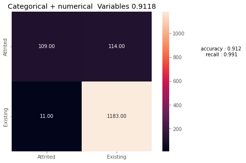

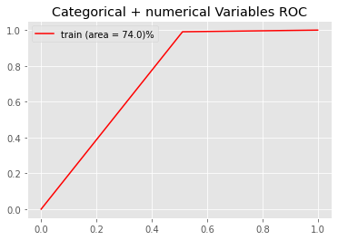

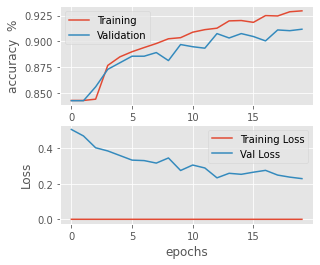

```
CPU times: user 6.28 s, sys: 1.34 s, total: 7.62 s
Wall time: 5 s
```

```python
%%time


model.compile(optimizer=keras.optimizers.Adam(),
              loss=tf.keras.losses.BinaryCrossentropy(),
              metrics=['accuracy'])


callback = tf.keras.callbacks.EarlyStopping(monitor='val_accuracy', patience=5)

weight_0 = 1/len(y_train[y_train==0])
weight_1 = 1/len(y_train[y_train==1])
class_weight = {0: weight_0, 1: weight_1}

history = model.fit([X_train_crossed,X_train_cat,X_train_num],
                    y_train_crossed,
                    epochs=20,
                    batch_size=128,
                    verbose=1,
                    callbacks=[callback],
                    validation_data = ([X_test_crossed,X_test_cat,X_test_num],y_test_crossed),
                    class_weight=class_weight)

yhat = model.predict([X_test_crossed,X_test_cat,X_test_num]) # each branch has an input

yhat = np.round(yhat)
print(mt.confusion_matrix(y_test_crossed,yhat))
print(mt.classification_report(y_test_crossed,yhat))

summarize_net(model,yhat,y_test_crossed.to_numpy(),"Categorical + numerical  Variables ")
plt.show()
plt.figure()
plot_roc(0,"Categorical + numerical Variables ROC",y_test_crossed.to_numpy(),yhat)
plot_train_val("accuracy ",history.history['accuracy'],history.history['val_accuracy'],history.history['loss'],history.history['val_loss'])
```

We get much better results crossing the same features while using our class weights. Although our accuracy and loss graphs look better when we don't use weights, this is compensated for by our confusion matrix, which is abysmal when we don't use weights. In this case, however, both classes have a precision of 91%, and accuracy is 91% as well, so this performs decently. Recall is 49% for the attrited customers; it could be worse, but it could certainly be better. The f1-score is also lower than we would've hoped for the attrited customers. However, this is certainly an improvement over the unweighted model from earlier.

```python
yhat = np.round(model.predict(X_test))
print(mt.confusion_matrix(y_test,yhat))
print(mt.classification_report(y_test,yhat))
```

[output not shown]

For the modeling section of this lab, we implemented and plotted many different wide and deep networks to compare the performance when you cross different features or add more layers. We also created a network that was deep but not wide to compare the performance of this network to the wide and deep network.

All of the analyses for every graph is written directly after we plot the confusion matrix and the graphs, but here are our findings in brief:

- Our model performed better when we added weights to the classes. This is because our classes were highly imbalanced (84% existing customers, 16% attrited customers) so adding weights helped balance these out.
- When we did not add weights, the majority of the time, our model predicted everyone to be an existing customer.
- A confusion matrix is far more significant in determining the model's effectiveness than just accuracy is, because in our case, an accuracy of 84% could still mean the model got every single attrited customer incorrect.
- The wide network (instead of wide and deep, we did only wide) did not perform that terribly. We didn't need the class weights using the wide network. However, our wide network did not perform as well as our best instance of a wide and deep network, weights included.
- We tried multiple wide and deep networks with two different numbers of layers. The smaller number of layers performed better than the larger number of layers.
- Our best instance of a wide and deep network was the instance we had after crossing features, adding class weights, and using the smaller amount of layers.
- We plotted graphs using recall, AUC, and accuracy to see what ended up being the best. Although optimizing recall was our final goal, it appears that our model did better when trained on AUC and accuracy metrics.